# Coursework Report

*N* removed NAs: 7

*N* removed <18: 23

**Correct typo age:** 21

*N* total clean: 138

| Group | *N* | *M*<sub>age</sub> | % green |
| --- | --- | --- | --- |
| Control | 70 | 21.03 | 34.29 |
| Experim | 68 | 20.88 | 57.35 |

| Gender | *N* | *M*<sub>age</sub> | % green |
| --- | --- | --- | --- |
| Male | 66 | 20.91 | 42.42 |
| Female | 47 | 20.81 | 49.65 |
| Other | 25 | 21.36 | 46.67 |

**Main analysis results**

**car:**  
χ<sup>2</sup>(1) = 3.51, *p* = .061

**cleaner:**  
χ<sup>2</sup>(1) = 6.57, *p* = .010

**dishwasher:**  
χ<sup>2</sup>(1) = 10.45, *p* = .001

[interactive chart not shown]

[figure not shown]

[interactive chart not shown]

# Coursework Report

Analysing Data, Spring 2020

# Methods

## Participants

*Table 1* Age Descriptives by Condition and Gender

[output not shown]

*Table 2* Age Descriptives by Condition

[output not shown]

*Table 3* Age Descriptives by Gender

[output not shown]

## Design

The conceptual hypothesis was that “Buying ‘green’ products is related to status motives”. The research question was: “Why do people choose to buy ‘green’ products?”.

The independent variable was the story condition, with the test being repeated three times. The story condition had two factors: control and status motive. The repetitions tested another independent variable, the product type, which had three factors: dishwasher, cleaner, and car. The status motive was elicited through the same method as the Griskevicius et al. (2010) study: a short story of around 700 words after which the reader’s salience of status dynamics is increased. Participants then chose whether they would purchase a luxury or green variation of each of the three product types. The difference between a luxury and a green product was that the green version in some way sacrificed functionality for the cause of being more environmentally freindly, whilst remaining the same price as the luxury variation. The dependent variable was the overall frequency of participants’ choices between product variations, and so was the frequency of a factor measurement with two levels (luxury choice and green choice).

The operational hypothesis was that “People in the high status condition choose the green products more often than people in the control condition”. This relationship was tested using the chi-squared test.

# Results

Participants’ choices of product variation were analysed by story condition. As tables 4, 5, and 6, and figures 1, 2, and 3 show, the frequency of choice of green product variation was higher in the status motive story condition than in the control condition for each of the three product types. This suggests that there is a positive association between status motive salience and motivation to purchase green variations of products.

*Table 4* Observed Frequencies of Dishwasher Product Variation Choices by Story Type

|  | Luxury Product | Green Product |
| --- | --- | --- |
| Control Story | 48 | 22 |
| Status Motive Story | 27 | 41 |

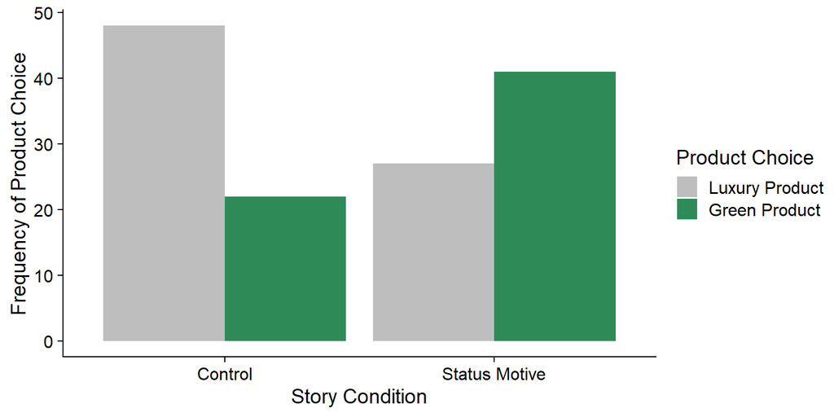

*Figure 1* Frequency of Dishwasher Product Choices by Story Type

*Table 5* Observed Frequencies of Cleaner Product Variation Choices by Story Type

|  | Luxury Product | Green Product |
| --- | --- | --- |
| Control Story | 49 | 21 |
| Status Motive Story | 32 | 36 |

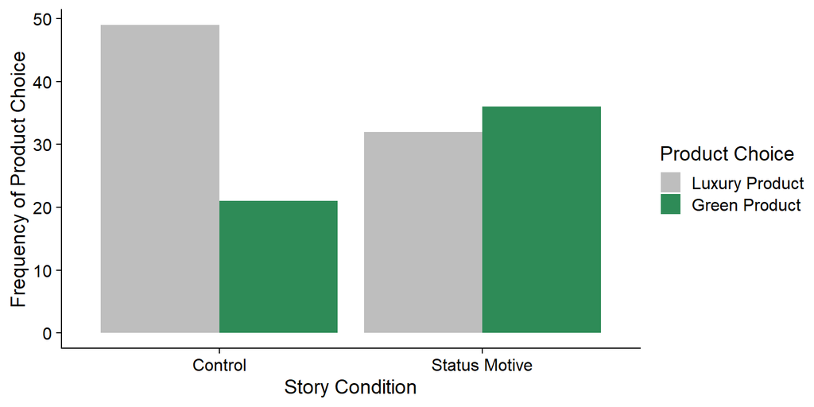

*Figure 2* Frequency of Cleaner Product Choices by Story Type

*Table 6* Observed Frequencies of Car Product Variation Choices by Story Type

|  | Luxury Product | Green Product |
| --- | --- | --- |
| Control Story | 40 | 29 |
| Status Motive Story | 28 | 40 |

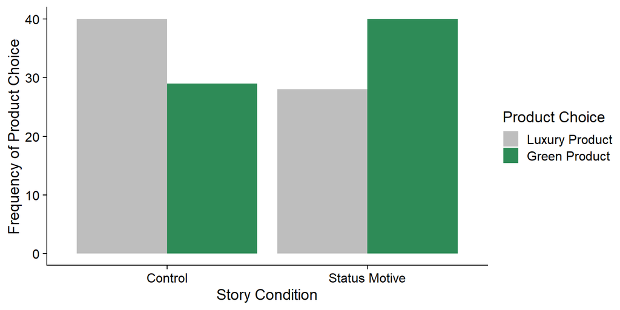

*Figure 3* Frequency of Car Product Choices by Story Type

# Discussion

The increase in frequency of green product choice from the control story type to the status motive story type suggests that status motive salience is positively associated with motivation to purchase green products. This supports our hypothesis, by demonstrating a relationship. This also provides information relating to the research question, suggesting that status is involved in a person’s choice to buy green products, perhaps to increase their status, or to demonstrate high status.

This study is a replication of Griskevicius et al.’s (2010) study. Our study largely produced the same pattern of results, with the exception of the non-signficant association we found for the car product type. However, Griskevicius et al. (2010) did find a significant positive association between status motive and choice of green car variation. Overall, findings of our replication study support the reliability of the findings of the original study, and so reinforce the hypothesis that buying ‘green’ products is related to status motives.

A potential avenue for further research on this topic would be the extent to which the effect of status motives of product choice is mediated by product type. For example, a further replication testing the association between status motive and choice of green car models would be beneficial to investigate the reliability of the findings of our study. This would be insightful as inferences could be made as to which qualities of a product could mediate the status effect. Griskevicius et al. (2010) found status motives only to lead people to buy green variations of products when their shopping is in public, not in private. This finding is in line with costly signalling theory and research on competitive altruism (Hardy & Van Vugt, 2006), which explain the status effect as individuals being willing to spend more resources or forgo luxuries in order simply to demonstrate to others their ability and capacity to do so. Acting prosocially and demonstrating abundance of resources in this way can convey high status. Therefore it may be worth researching which aspects of green product variations are most able to communicate high status in this way. For example, we found their to be a positive association between choice of green cleaner and status motive (*χ*<sup>2</sup>(1) = 6.57, *p* = .010), despite this being a product which very few people would know the consumer would own. This is in contrast to a choice of car or dishwasher, which would more practically display to others one’s altruistic choice. Perhaps a further replication with a range of product types with distinctly varying levels of visibilty to others could demostrate any potential mediating effect of product visibility on the status motive effect.

Pragmatically, the concept of status motives driving intention to purchase green products could be beneficial to the pro-environmental cause. In marketing, companies could prime consumers to consider their status, and so the effect of their product choice on their status as displayed by their altruism, to encourage them to purchase green products. This could be done through advertising campaigns, for example by showing wealthy, high-status, altruistic people driving environmentally friendly cars, thus reinforcing the association between green products and competitive altruism. This also comes with an economic incentive, as there is no need to reduce the price of green products in order to drive up sales. In fact, an increased price may even be more beneficial (Griskevicius et al., 2010). The same method could be applied through media, with green products being displayed often alongside scenarios surrounding competition for status. In short, priming consumers to (even subconsciously) consider their status when encountering choices between luxury and green variations of products could have a significant impact on the proportion of pro-environmental choices consumers make.

In conclusion, our findings reinforce those of Griskevicius et al. (2010): that when primed with status motive salience, people are more inclined to choose ‘green’ variations of products over luxury variations. This concept could have profound implications for potential tactics to increase consumers’ choices of pro-environmental products, and so could be significantly beneficial to the pro-environmental cause.

# References

Griskevicius, V., Tybur, J., & Van den Bergh, B. (2010). Going Green to Be Seen: Status, Reputation, and Conspicuous Conservation. Journal of Personality and Social Psychology, 98(3), 392-404.

Hardy, C., & Van Vugt, M. (2006). Nice Guys Finish First: The Competitive Altruism Hypothesis. Personality and Social Psychology Bulletin, 32(10), 1402-1413.